# Week 1: Statistical Foundations and Study Design

Introduction to Statistics for Animal Science

Author

AnS 500 - Fall 2025

Published

October 22, 2025

# 1 Introduction: Why Statistics Matter in Animal Science

Imagine you’re a swine nutritionist testing a new feed additive that claims to improve growth rates. After a 90-day trial, you observe that pigs fed the new additive weigh an average of 5 kg more than the control group. **Is this difference real, or just random variation?** Should you recommend this expensive additive to producers?

Or perhaps you’re a beef geneticist comparing two breeding programs. Bulls from Program A seem to produce offspring with slightly better marbling scores. **But is the difference large enough to justify changing breeding protocols?**

These are the types of questions statistics helps us answer. Statistics is fundamentally about **making decisions in the presence of uncertainty**. In animal science, we deal with biological variation constantly—no two animals are exactly alike, even if they’re raised identically. Statistics gives us a framework to:

1. **Quantify** patterns and relationships in our data
2. **Distinguish** real effects from random noise
3. **Make inferences** about populations based on samples
4. **Communicate** our findings with appropriate levels of confidence

In this course, we’ll build your statistical toolkit step by step, always connecting concepts back to real problems in animal agriculture.

**NoteThe Big Picture**

Statistics won’t give you perfect certainty—that’s impossible in biology. Instead, it helps you quantify how confident you should be in your conclusions and communicate that uncertainty honestly.

# 2 The Two Statistical Philosophies

Before diving into specific methods, it’s important to understand that there are two major frameworks for thinking about probability and inference: **Frequentist** and **Bayesian** statistics. While this course focuses on frequentist methods (the dominant approach in agricultural sciences), being aware of both perspectives will make you a more sophisticated consumer of research.

## 2.1 Frequentist Statistics

The frequentist approach defines **probability as long-run frequency**. If we say “the probability of getting heads is 0.5,” we mean that if we flipped a coin infinitely many times, about half would be heads.

### 2.1.1 Key Principles

1. **Parameters are fixed but unknown**: The true average weight of pigs on a new diet is a fixed number—we just don’t know it. Our job is to estimate it from data.
2. **Probability describes data, not hypotheses**: We calculate “the probability of observing data this extreme if the null hypothesis were true,” NOT “the probability that the hypothesis is true.”
3. **Repetition is key**: Frequentist inference imagines repeating the same experiment many times. Confidence intervals and p-values only make sense in this framework of repeated sampling.

### 2.1.2 Example: Feed Trial

Suppose we test a new feed supplement in pigs. The frequentist asks:

> “If this supplement truly had no effect (null hypothesis), what’s the probability we’d observe a difference this large just by chance?”

If that probability is very small (say, p < 0.05), we conclude the data are **incompatible** with the null hypothesis, and we reject it in favor of the alternative (the supplement does have an effect).

**ImportantCritical Point**

A p-value of 0.03 does **NOT** mean “there’s a 3% chance the null hypothesis is true.” It means “if the null were true, we’d see data this extreme only 3% of the time by chance alone.”

## 2.2 Bayesian Statistics

The Bayesian approach defines **probability as degree of belief**. It explicitly incorporates prior knowledge and updates that knowledge with data.

### 2.2.1 Key Principles

1. **Parameters have probability distributions**: Instead of saying “the true effect is unknown,” Bayesians say “our belief about the effect can be described by a probability distribution.”
2. **Prior + Data = Posterior**: Bayesian analysis combines:
   - **Prior**: What we believed before seeing the data
   - **Likelihood**: What the data tell us
   - **Posterior**: Updated beliefs after seeing the data
3. **Direct probability statements about hypotheses**: Bayesians can say things like “there’s an 85% probability the effect is positive” or “the treatment effect is between 2 and 8 kg with 95% probability.”

### 2.2.2 Bayes’ Theorem

The mathematical foundation of Bayesian statistics is Bayes’ Theorem:

$$P(\theta | \text{data}) = \frac{P(\text{data} | \theta) \times P(\theta)}{P(\text{data})}$$

Where:

- $P(\theta | \text{data})$ = **Posterior**: Our updated belief about parameter $\theta$ after seeing the data
- $P(\text{data} | \theta)$ = **Likelihood**: How probable our data are under different values of $\theta$
- $P(\theta)$ = **Prior**: Our belief about $\theta$ before seeing the data
- $P(\text{data})$ = **Marginal likelihood**: A normalizing constant (probability of data across all possible $\theta$)

### 2.2.3 Example: Same Feed Trial, Bayesian Perspective

A Bayesian might start with prior knowledge: “Previous studies suggest feed supplements increase growth by 0-10 kg, with most around 3-5 kg.” After seeing the data, they update this prior to a posterior distribution and can make statements like:

> “Based on our data, there’s a 92% probability that the supplement increases weight by at least 2 kg, and a 70% probability the increase is between 4 and 8 kg.”

## 2.3 Comparing the Approaches

| Aspect | Frequentist | Bayesian |
| --- | --- | --- |
| Definition of Probability | Long-run frequency | Degree of belief |
| Parameters | Fixed, unknown constants | Random variables with distributions |
| Prior Knowledge | Not formally incorporated | Explicitly incorporated via priors |
| Output | p-values, confidence intervals | Posterior distributions, credible intervals |
| Interpretation | Based on hypothetical repetition | Direct probability statements |

**TipWhy Frequentist in This Course?**

Frequentist methods are:

- More commonly used in animal science journals
- Required by many regulatory bodies (FDA, EPA)
- Computationally simpler for basic analyses
- The foundation for most statistical software defaults

However, Bayesian methods are growing in popularity, especially for complex models. Being fluent in frequentist thinking first makes learning Bayesian approaches easier later.

# 3 Understanding P-Values

P-values are perhaps the most misunderstood concept in statistics. Let’s build a proper understanding from the ground up.

## 3.1 Definition and Meaning

A **p-value** is defined as:

$$p = P(\text{data as extreme or more extreme} \mid H_0 \text{ is true})$$

Where:

- $P(\cdot)$ = Probability
- $\mid$ = “given that” or “conditional on”
- $H_0$ = The null hypothesis (typically “no effect” or “no difference”)

**In plain English**: The p-value is the probability of observing results at least as extreme as what we actually observed, **assuming the null hypothesis is true**.

### 3.1.1 Breaking Down the Definition

Let’s unpack each part:

1. **“Probability of observing results…”** – We’re talking about data, not hypotheses
2. **“…at least as extreme…”** – Not just exactly what we saw, but anything further from what we’d expect under the null
3. **“…assuming the null hypothesis is true”** – This is a conditional probability; we’re starting with an assumption

**WarningThe p-value is NOT:**

- ❌ The probability that the null hypothesis is true: $P(H_0 | \text{data})$
- ❌ The probability that the result occurred by chance
- ❌ The probability of making a wrong decision
- ❌ The size or importance of an effect
- ❌ The probability that replicating the study would give the same result

## 3.2 Visualizing What P-Values Mean

Let’s simulate a situation to build intuition. Suppose we’re comparing two groups of beef cattle (Control vs Treatment), and in reality, there’s **no true difference** between them (null hypothesis is true).

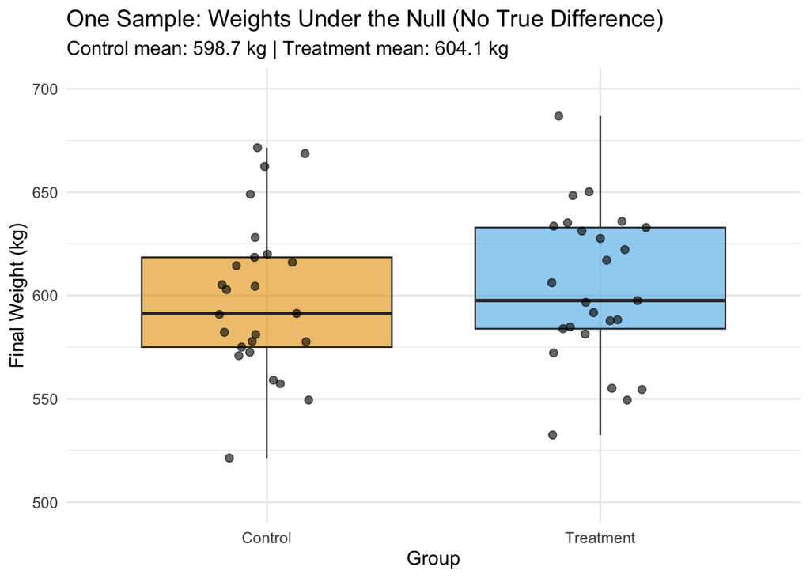

```r
# Simulation parameters
n_per_group <- 25
true_mean <- 600  # kg, both groups
true_sd <- 40

# Generate ONE sample where null is true
set.seed(123)
control <- rnorm(n_per_group, mean = true_mean, sd = true_sd)
treatment <- rnorm(n_per_group, mean = true_mean, sd = true_sd)

# Combine into data frame
sample_data <- tibble(
  weight = c(control, treatment),
  group = rep(c("Control", "Treatment"), each = n_per_group)
)

# Visualize
p1 <- ggplot(sample_data, aes(x = group, y = weight, fill = group)) +
  geom_boxplot(alpha = 0.6, outlier.shape = NA) +
  geom_jitter(width = 0.15, alpha = 0.6, size = 2) +
  scale_fill_manual(values = c("Control" = "#E69F00", "Treatment" = "#56B4E9")) +
  labs(
    title = "One Sample: Weights Under the Null (No True Difference)",
    subtitle = sprintf("Control mean: %.1f kg | Treatment mean: %.1f kg",
                      mean(control), mean(treatment)),
    y = "Final Weight (kg)",
    x = "Group"
  ) +
  theme(legend.position = "none") +
  ylim(500, 700)

print(p1)
```

```r
# Run t-test
test_result <- t.test(control, treatment)
cat(sprintf("\nObserved difference: %.1f kg\n", mean(treatment) - mean(control)))
```

```
Observed difference: 5.4 kg
```

```r
cat(sprintf("P-value: %.4f\n", test_result$p.value))
```

```
P-value: 0.6100
```

Even though the null hypothesis is **true** (both groups have the same mean), we observe a difference just due to random sampling. The p-value tells us how “surprising” this observed difference would be if the null were true.

### 3.2.1 The Distribution of P-Values Under the Null

Now, what happens if we repeat this experiment 1,000 times, always with no true difference?

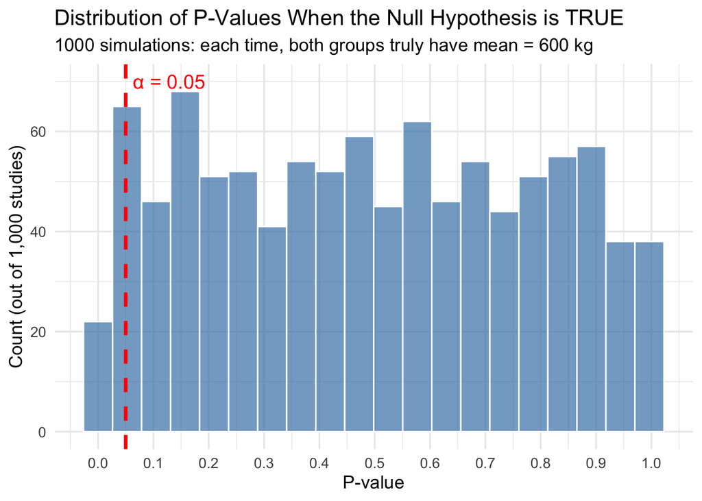

```r
# Simulate 1000 experiments where null is true
n_simulations <- 1000

simulate_study <- function() {
  control <- rnorm(n_per_group, mean = true_mean, sd = true_sd)
  treatment <- rnorm(n_per_group, mean = true_mean, sd = true_sd)
  t.test(control, treatment)$p.value
}

p_values <- replicate(n_simulations, simulate_study())

# Visualize distribution
p2 <- tibble(p_value = p_values) %>%
  ggplot(aes(x = p_value)) +
  geom_histogram(bins = 20, fill = "steelblue", alpha = 0.7, color = "white") +
  geom_vline(xintercept = 0.05, color = "red", linetype = "dashed", linewidth = 1.2) +
  annotate("text", x = 0.05, y = 70, label = "α = 0.05",
           color = "red", hjust = -0.1, size = 5) +
  labs(
    title = "Distribution of P-Values When the Null Hypothesis is TRUE",
    subtitle = sprintf("%d simulations: each time, both groups truly have mean = %d kg",
                      n_simulations, true_mean),
    x = "P-value",
    y = "Count (out of 1,000 studies)"
  ) +
  scale_x_continuous(breaks = seq(0, 1, 0.1)) +
  theme_minimal(base_size = 13)

print(p2)
```

```r
# Calculate proportion "significant"
prop_sig <- mean(p_values < 0.05)
cat(sprintf("\nProportion of p-values < 0.05: %.3f (expected: 0.05)\n", prop_sig))
```

```
Proportion of p-values < 0.05: 0.062 (expected: 0.05)
```

```r
cat(sprintf("Out of %d studies where null is TRUE, %d (%.1f%%) would be \"significant\" at p < 0.05\n",
            n_simulations, sum(p_values < 0.05), 100 * prop_sig))
```

```
Out of 1000 studies where null is TRUE, 62 (6.2%) would be "significant" at p < 0.05
```

**ImportantCritical Insight**

When the null hypothesis is **true**, p-values are uniformly distributed between 0 and 1. This means about 5% of studies will produce p < 0.05 purely by chance—this is the **Type I error rate** (false positive rate).

If you use α = 0.05 as your threshold, you’re accepting that 5% of the time, you’ll incorrectly reject a true null hypothesis.